# Census Investigation

David Parsons

February 2, 2017

[Rutgers Data 101 Blog](http://data101.cs.rutgers.edu/?q=blog)

My Data Exploration Homepage

[Rutgers Data 101 Homepage](http://data101.cs.rutgers.edu/)

## Introduction

This investigation is in response to a course assignment for my CS 142 class. We we’re provided with a synthetic data set that had artificial patterns created with in it for us to find.

## The Data

Data Provided by Professor Imenlinski as part of a CS 142 Assignment.

```r
census <- read.csv("CENSUSNEW.csv")
summary(census)
```

```
##       AGE                     STATUS             EDUCATION
##  Min.   :20.00   Private         :20836   HS-grad     :9842
##  1st Qu.:29.00   Self-emp-not-inc: 2515   Some-college:6434
##  Median :38.00   Local-gov       : 2062   Bachelors   :5340
##  Mean   :39.98   ?               : 1468   Masters     :1753
##  3rd Qu.:49.00   State-gov       : 1243   Assoc-voc   :1375
##  Max.   :95.00   Self-emp-inc    : 1108   Assoc-acdm  :1055
##                  (Other)         :  994   (Other)     :4427
##      YEARS                 PROFESSION    CAPITALGAINS     CAPITALLOSS
##  Min.   : 1.00   Prof-specialty :4050   Min.   :     0   Min.   :     0
##  1st Qu.: 9.00   Exec-managerial:4036   1st Qu.:     0   1st Qu.:     0
##  Median :10.00   Craft-repair   :4004   Median :     0   Median :     0
##  Mean   :10.18   Adm-clerical   :3471   Mean   : 27441   Mean   :  1072
##  3rd Qu.:13.00   Sales          :3235   3rd Qu.:   304   3rd Qu.:     0
##  Max.   :16.00   Other-service  :2716   Max.   :600074   Max.   :296988
##                  (Other)        :8714
##            NATIVE       ELEMENTS
##  United-States:26903   Earth:7544
##  Mexico       :  599   Fire :7550
##  ?            :  556   Metal:7645
##  India        :  198   Wood :7487
##  Philippines  :  191
##  Germany      :  131
##  (Other)      : 1648
```

Each data point was representative of a single person and how they fit into the following:

```
age
status - empolyeement
education - education level
years - work experience
profession - current career
capital gains
capital loss
native - country
elements - "signs"
```

I did some initial set creation so I could more easily iterate over the categories of the data frame. This came in handy later when created my own functions and used for-each loops to create lots of plots with little repetition on my part.

```r
# Creates Dictionary of Numerics
nums <- c("AGE", "YEARS", "CAPITALNET")
# Creates Dictionary of Elements
elems <- levels(census$ELEMENTS)
# Non Element cats
cats <- c("AGE", "STATUS", "EDUCATION", "PROFESSION", "NATIVE")
```

```r
# Creates Net Capital Variable
census$CAPITALNET = census$CAPITALGAINS - census$CAPITALLOSS
# Summary with CAPITALNET
summary(census)
```

```
##       AGE                     STATUS             EDUCATION
##  Min.   :20.00   Private         :20836   HS-grad     :9842
##  1st Qu.:29.00   Self-emp-not-inc: 2515   Some-college:6434
##  Median :38.00   Local-gov       : 2062   Bachelors   :5340
##  Mean   :39.98   ?               : 1468   Masters     :1753
##  3rd Qu.:49.00   State-gov       : 1243   Assoc-voc   :1375
##  Max.   :95.00   Self-emp-inc    : 1108   Assoc-acdm  :1055
##                  (Other)         :  994   (Other)     :4427
##      YEARS                 PROFESSION    CAPITALGAINS     CAPITALLOSS
##  Min.   : 1.00   Prof-specialty :4050   Min.   :     0   Min.   :     0
##  1st Qu.: 9.00   Exec-managerial:4036   1st Qu.:     0   1st Qu.:     0
##  Median :10.00   Craft-repair   :4004   Median :     0   Median :     0
##  Mean   :10.18   Adm-clerical   :3471   Mean   : 27441   Mean   :  1072
##  3rd Qu.:13.00   Sales          :3235   3rd Qu.:   304   3rd Qu.:     0
##  Max.   :16.00   Other-service  :2716   Max.   :600074   Max.   :296988
##                  (Other)        :8714
##            NATIVE       ELEMENTS      CAPITALNET
##  United-States:26903   Earth:7544   Min.   :-251235
##  Mexico       :  599   Fire :7550   1st Qu.:      0
##  ?            :  556   Metal:7645   Median :      0
##  India        :  198   Wood :7487   Mean   :  26369
##  Philippines  :  191                3rd Qu.:    300
##  Germany      :  131                Max.   : 600074
##  (Other)      : 1648
```

At this point I had the data loaded and ready for analysis.

## Investigation

The following is the step by step thought process I followed in exploring this data set and arriving at the conclusion I did.

### Initial Elemental Plots

I started by plotting elements against each category, as there had been an initial hint that some patterns may lie in the Elements.

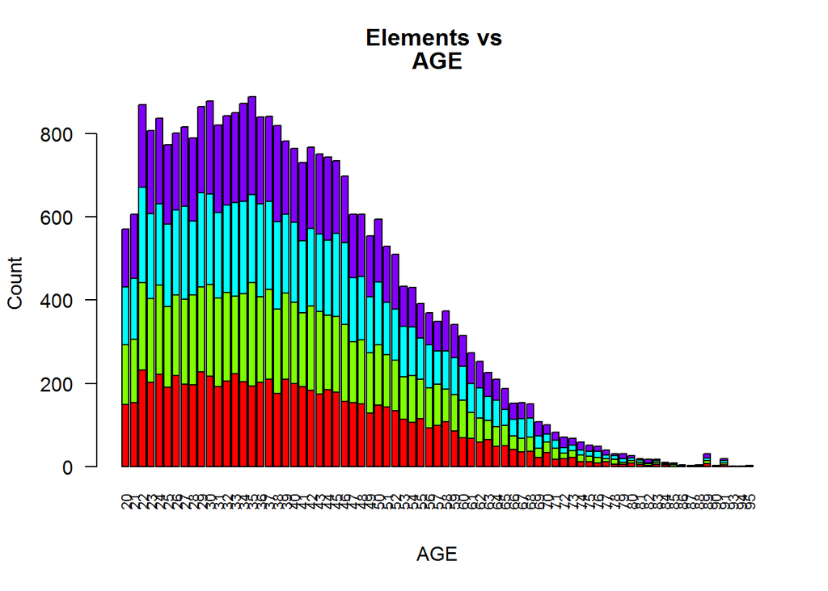

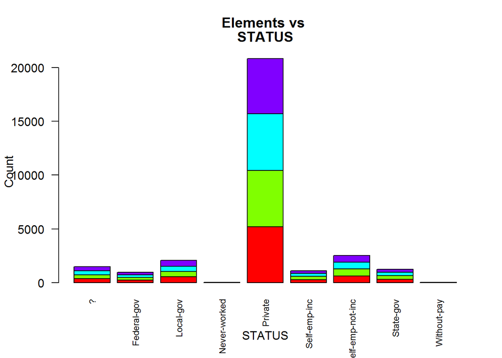

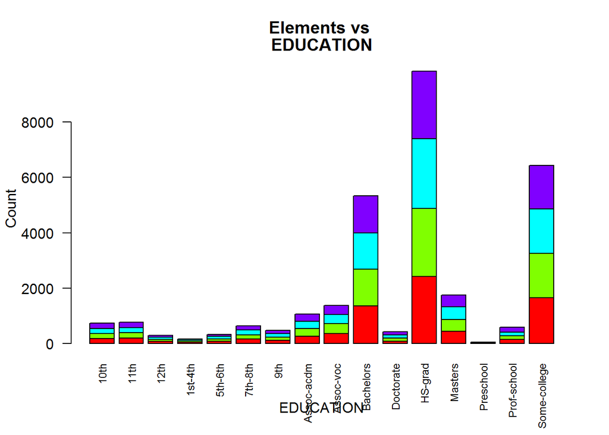

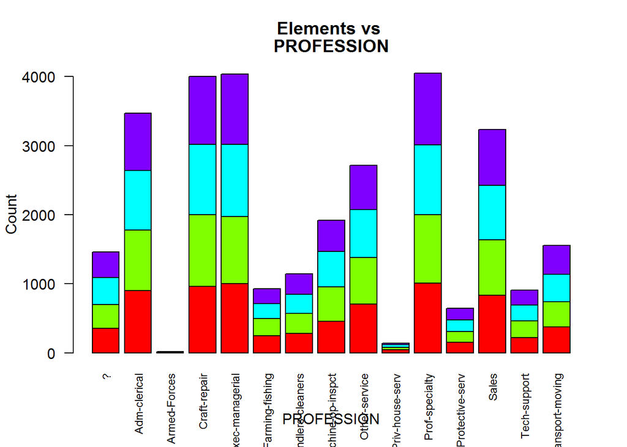

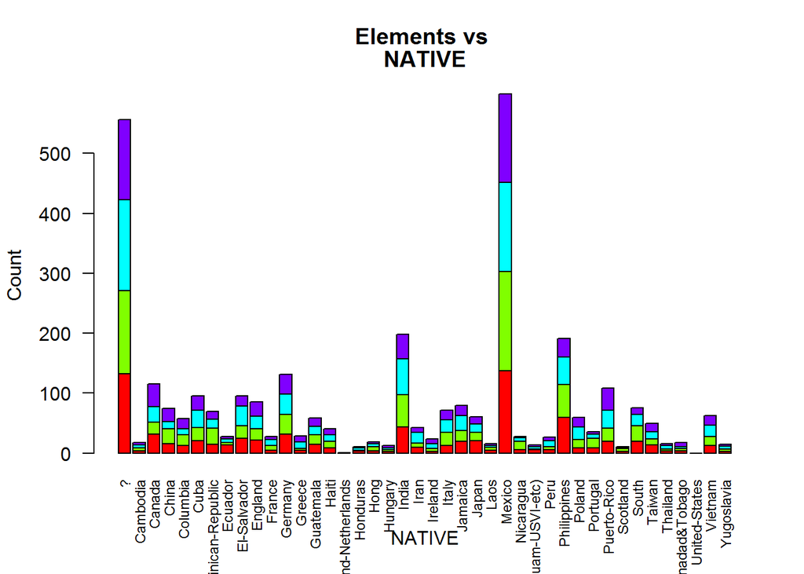

```r
bplotAll <- function(subCat){

  subCen <- census

  if(subCat == "NATIVE"){
  subCen <- subset(subCen, NATIVE != "United-States")
  }

  tmpTab <- table(subCen$ELEMENTS, subCen[,subCat])

  barplot(tmpTab, main=c("Elements vs ", subCat), xlab = subCat, ylab = "Count", col = rainbow(4), las = 2, cex.names = 0.75, beside = FALSE, horiz = FALSE)
}

for(cat in cats){
  bplotAll(cat)
}
```

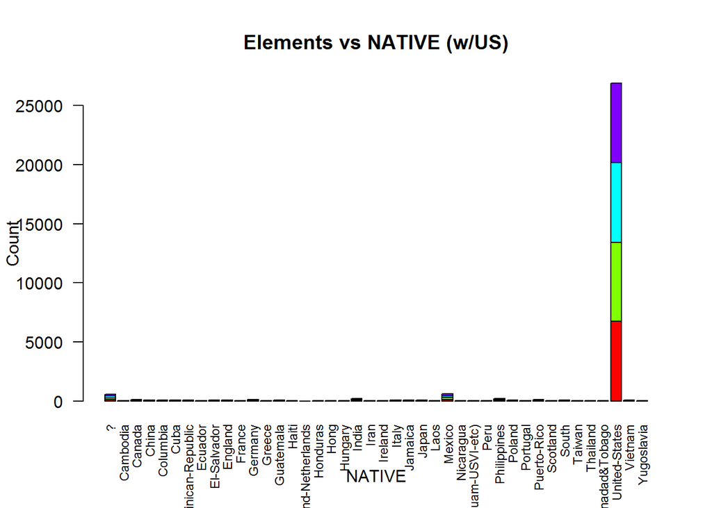

```r
### NATIVE Plot With US

barplot(tmpTab <- table(census$ELEMENTS, census$NATIVE), main="Elements vs NATIVE (w/US)", xlab = "NATIVE", ylab = "Count", col = rainbow(4), las = 2, cex.names = 0.75, beside = FALSE, horiz = FALSE)
```

But these only revealed to me how much the United States Skewed the Native Data.

### Mean Country Capital by Element

Then I plotted the mean Capital Net, Gain, and Net for each element by country.

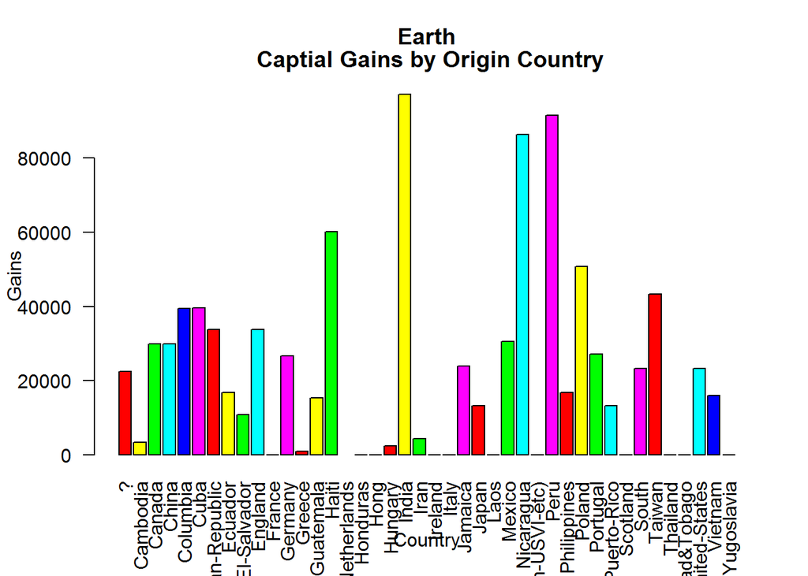

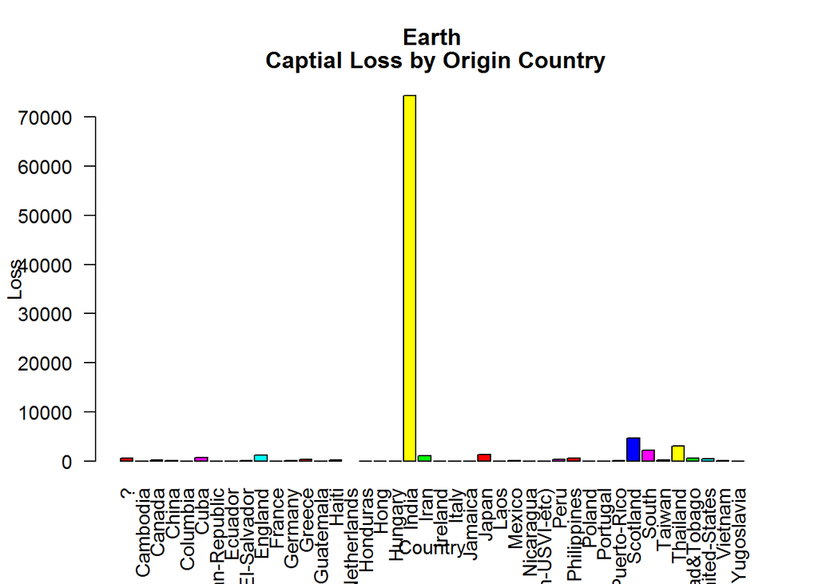

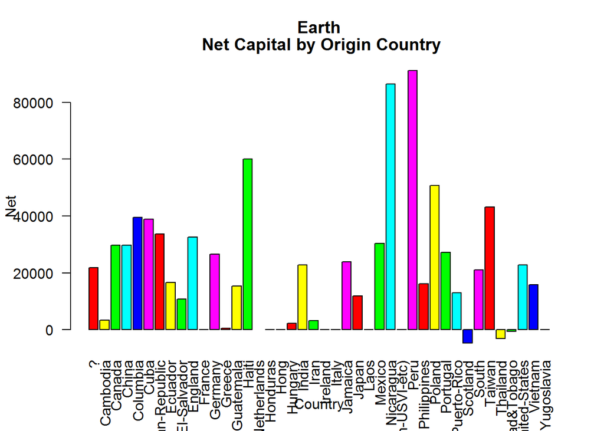

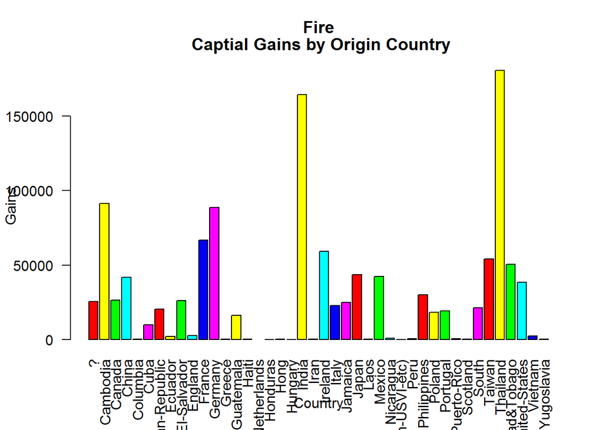

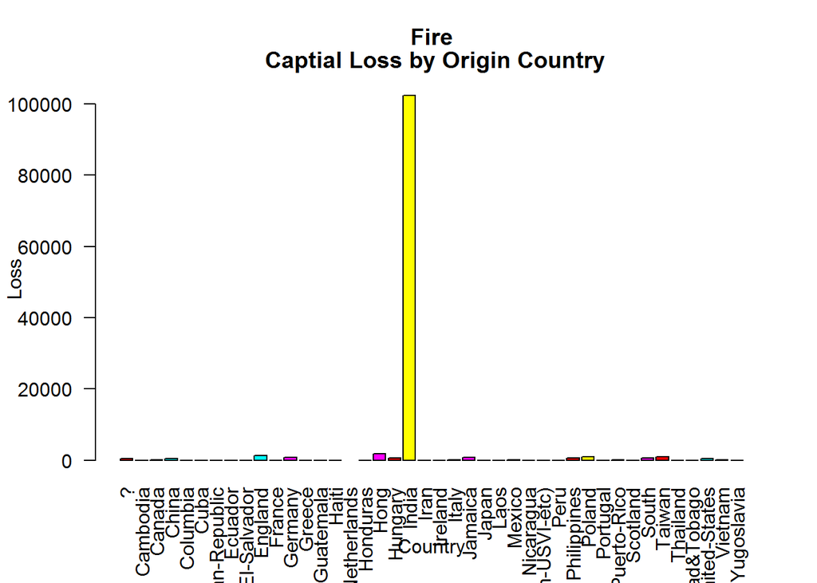

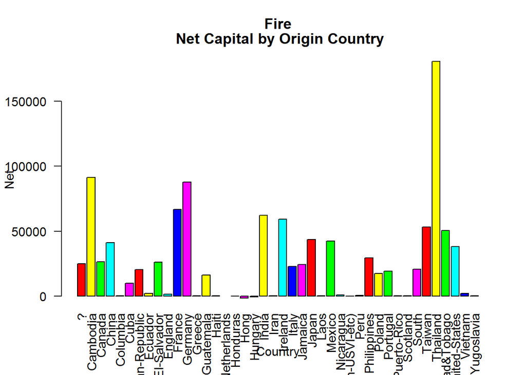

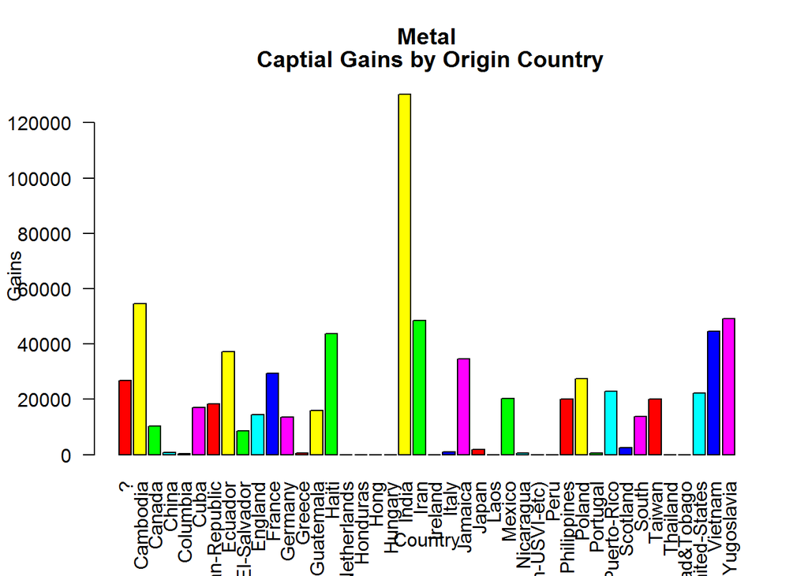

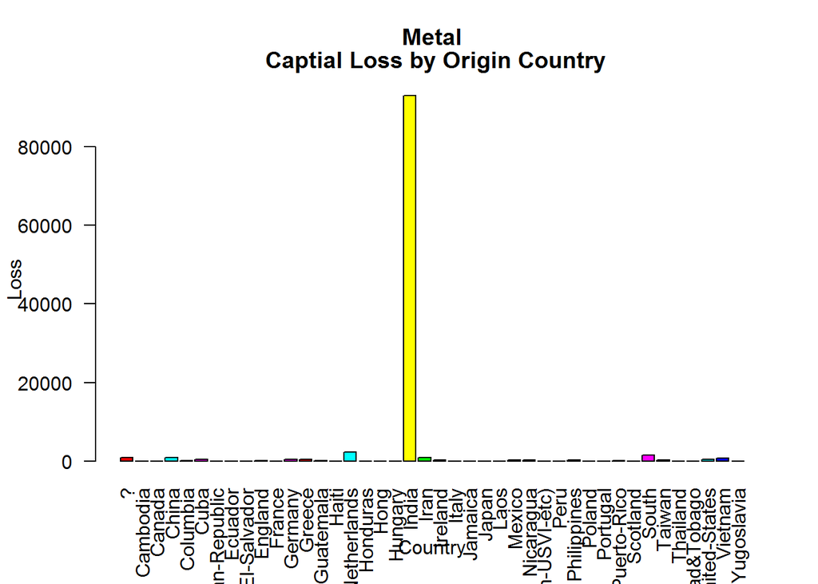

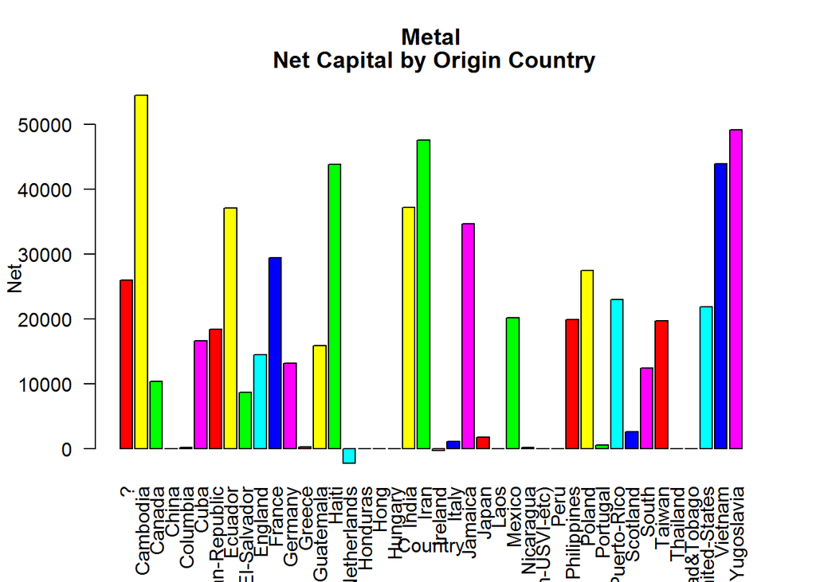

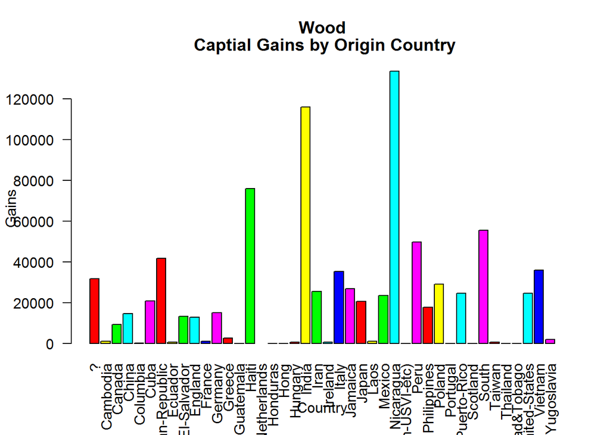

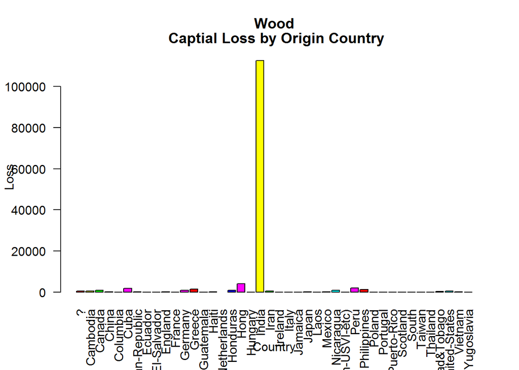

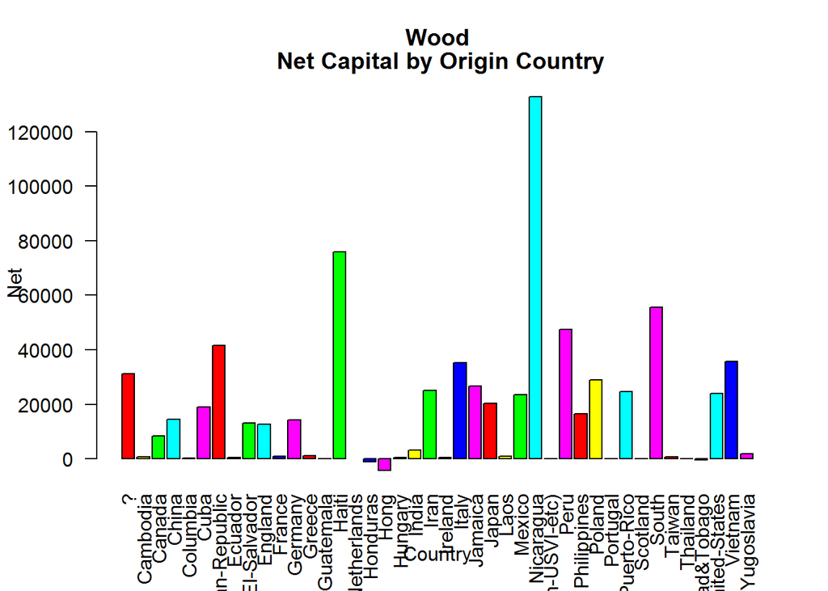

```r
plotBar <- function(e) {
  subCen <- subset(census, ELEMENTS == e)# & NATIVE != "India")

  subCen.meanCapG <- tapply(subCen$CAPITALGAINS, subCen$NATIVE, mean)
  barplot(subCen.meanCapG, las = 2, main=c(e," Captial Gains by Origin Country"), xlab = "Country", ylab = "Gains", col = rainbow(6), las = 2)

  subCen.meanCapL <- tapply(subCen$CAPITALLOSS, subCen$NATIVE, mean)
  barplot(subCen.meanCapL, las = 2, main=c(e," Captial Loss by Origin Country"), xlab = "Country", ylab = "Loss", col = rainbow(6), las = 2)

  subCen$CAPITALNET <- (subCen$CAPITALGAINS - subCen$CAPITALLOSS)
  subCen.meanNet <- tapply(subCen$CAPITALNET, subCen$NATIVE, mean)
  barplot(subCen.meanNet, las = 2, main=c(e," Net Capital by Origin Country"), xlab = "Country", ylab = "Net", col = rainbow(6), las = 2)

}

for (elem in elems){
  plotBar(elem)
}
```

A noticed a few small things from these graphs:

```
- $150,000+ Mean Net Capital for Thailand Natives with Fire Elements
- $120,000+ Mean Net Capital for Nicaragua Natives with Wood Elements
- And huge Gains & Losses for India Natives of any elements (resulting in a low net.)
```

But otherwise, these graphs revealed revealed very little to me about any advantages as far as element.

### Net Captial vs Age by Country

My next idea was to plot Net Capital Gains & Age for every country using a scatter plot (Net Capital vs Age).

```r
plotScat <- function(e){
  subCen <- subset(census, NATIVE == e)

  subCen$CAPITALNET <- (subCen$CAPITALGAINS - subCen$CAPITALLOSS)
  plot(subCen$CAPITALNET, subCen$AGE, col = rainbow(8), main = c("Net Capital vs Age", e), las = 2, xlab = "Net Capital", ylab = "Age")

}

for(country in levels(census$NATIVE)){
  plotScat(country)
}
```

[output not shown]

There we a lot of graphs created, and I’ve yet to figure out how to only include ceratin plots using Rmd. But here are the key take a ways:

```
- United States
    - Almost no Net Loss
    - No one over the age of about 40 had over $300,000
    - Large concentration of 20-40 year olds with $400,000 to $600,000
- Inida
    - Large spread of -$200,000 to +$200,000
    - Shows explanation of bar graphs from before
- Mexico
    - Moderate Concentraction from $200,000 to $300,000
- All Others
    - Most had concentrations around $0
    - Any Positive Means were usually the product of just a few outliers with extreme values
```

### Heat Maps

I’ll admit. I went a little crazy here.

But in my defense I found these heat maps very interesting for detecting little correlations amount all these values.

Most correlations were easily explained by outliers, but some were still somewhat interesting.

```r
heatPlot <- function(yAxis, xAxis, heat) {
  subCen <- subset(census)#, CAPITALNET > 200000)
  # print(summary(tapply(subCen[,yAxis])))
  print(ggplot(data = subCen, aes(x = subCen[,xAxis], y = subCen[,yAxis]), las = 2)+ labs(x = xAxis, y = yAxis, las = 2) + geom_tile(aes(fill = census[,heat]))+
  scale_fill_gradient2(low="darkblue", high="red", guide="colorbar") + theme(axis.text.x = element_text(angle = 90, hjust = 1)))
}
for(var in cats){
  for(val in nums){
    for(fin in c("ELEMENTS")){
      heatPlot(var, fin, val)
    }
  }
}
for(var in cats){
  for(val in nums){
    for(fin in cats){
      heatPlot(var, fin, val)
    }
  }
}
```

[output not shown]

Again there were a ton graphs created, the source code for this project is on my [Github](https://github.com/Parsons-David/Data-Exploration) so you can check it out there and run it yourself if you want to see any of these graphs. But here are the key take a ways:

```
- France
    - France & Fire - Very high Net Capital
    - France & ? – Similar very high Net Capital
    - This is easily attributed to a single person skewing the mean.
- 9th Grade Education & Fire
    - Very high mean Net Capital for Fire Element respondents who dropped out in 9th grade
    - Similar story with single skew
```

## Notes and Comments

I was a little less excited/interested with this Data set than my previous attempt at Data Analysis.

A lot of the analysis felt forced, since I knew there was something that I was supposed to be looking for.

That being said I was proud of the methods that I wrote, that combined with the category sets, made it really quick and easy to plot lots of different categories against each other. The programming style reminded me a a mix between JavaScript and Python.

In the future I’d like to focus more on creating more compact/cleaner heat maps that more intuitively convey data patterns.

I look forward to furthering my Data Analysis skills on my next project.

[Rutgers Data 101 Blog](http://data101.cs.rutgers.edu/?q=blog)

My Data Exploration Homepage

[Rutgers Data 101 Homepage](http://data101.cs.rutgers.edu/)